# Homework2

Maria C. Codlin

# Homework 2

Every Saturday, at the same time, a primatologist goes and sits in the forest in the morning and listens for titi monkey calls, counting the number of calls they hear in a 2 hour window from 5am to 7am. Based on previous knowledge, she believes that the mean number calls she will hear in that time is exactly 15. Let X represent the appropriate Poisson random variable of the number of calls heard in each monitoring session.

What is the probability that she will hear more than 8 calls during any given session? What is the probability that she will hear no calls in a session? What is the probability that she will hear exactly 3 calls in a session? Plot the relevant Poisson mass function over the values in range 0 ≤ x ≤ 30. Simulate 104 results from this distribution (i.e., 2 years of Saturday monitoring sessions). Plot the simulated results using hist() and use xlim() to set the horizontal limits to be from 0 to 30. How does your histogram compare to the shape of the probability mass function you plotted above?

## Notes on Poisson from R-tutor (Ignore this bit, this is notes for me)

http://www.r-tutor.com/elementary-statistics/probability-distributions/poisson-distribution Poisson Distribution

The Poisson distribution is the probability distribution of independent event occurrences in an interval. If λ is the mean occurrence per interval, then the probability of having x occurrences within a given interval is:

[output not shown]

Solution The probability of having sixteen or less cars crossing the bridge in a particular minute is given by the function ppois.

```r
ppois(16, lambda=12)   # lower tail
```

```
## [1] 0.898709
```

```r
#[1] 0.89871
#Hence the probability of having seventeen or more cars crossing the bridge in a minute is in the upper tail of the probability density function.

ppois(16, lambda=12, lower=FALSE)   # upper tail
```

```
## [1] 0.101291
```

```r
#[1] 0.10129
#Answer: If there are twelve cars crossing a bridge per minute on average, the probability of having seventeen or more cars crossing the bridge in a particular minute is 10.1%.
```

# Answers

## What is the probability that she will hear more than 8 calls during any given session?

```r
round(ppois(8, lambda=15, lower.tail=FALSE), 3)
```

```
## [1] 0.963
```

## What is the probability that she will hear no calls in a session?

```r
round(ppois(0, lambda=15),7)
```

```
## [1] 3e-07
```

## What is the probability that she will hear exactly 3 calls in a session?

```r
round(dpois(3, lambda=15),5) #dpois is exact while ppois is with tail
```

```
## [1] 0.00017
```

## Plot the relevant Poisson mass function over the values in range 0 ≤ x ≤ 30

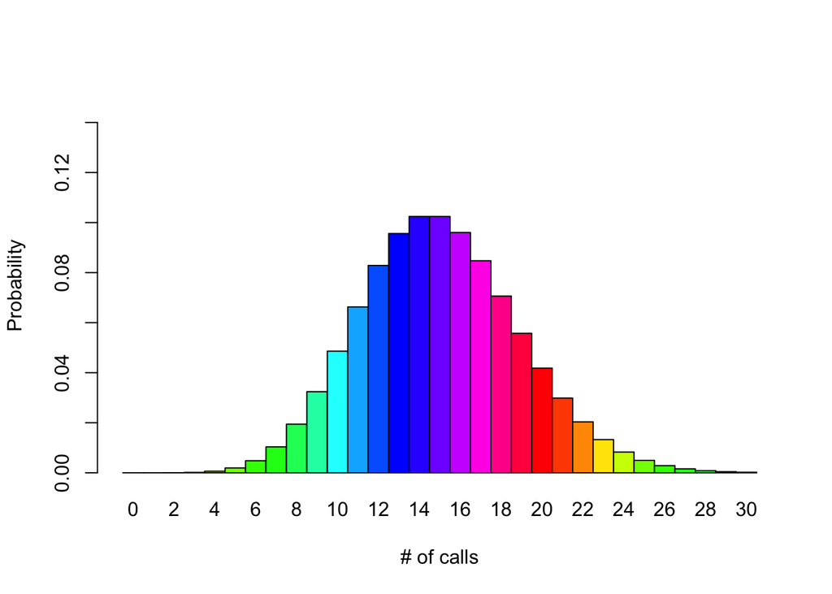

```r
barplot(dpois(x=0:30, lambda=15), ylim=c(0,0.15), space=0, names.arg=0:30, ylab="Probability", xlab="# of calls", col=rainbow(20))
```

## Simulate 104 results from this distribution (i.e., 2 years of Saturday monitoring sessions). Plot the simulated results using hist() and use xlim() to set the horizontal limits to be from 0 to 30. How does your histogram compare to the shape of the probability mass function you plotted above?

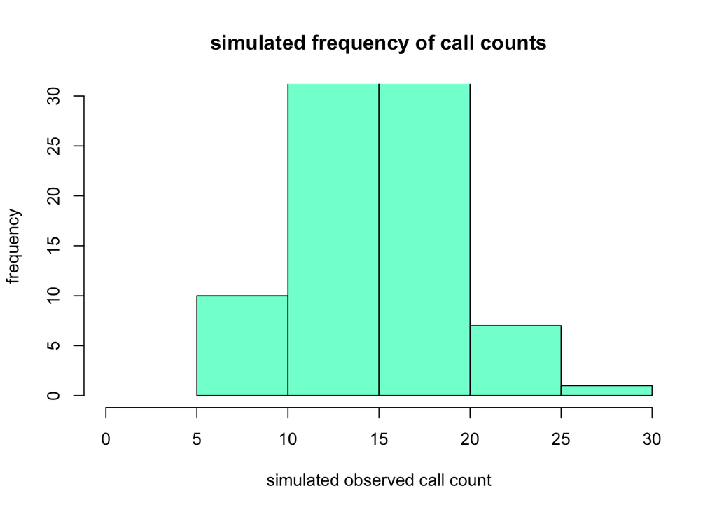

```r
sim<-rpois(n=104, lambda=15)
hist(sim, ylim=c(0,30), xlim=c(0,30), ylab="frequency", xlab="simulated observed call count", main="simulated frequency of call counts", col="aquamarine")
```

This histogram shows the simulated frequency of observed calls over a two year period. It generally seems to be a fair approximation of a normal distribution.

[figure not shown]